# CORRELAÇÃO EM R

## **INTRODUÇÃO**

Existe relação entre X e Y? Essa é uma pergunta recorrente na vida de qualquer pesquisador. Por exemplo, ao afirmar que a taxa de suicídio entre protestantes é maior do que entre católicos, Durkheim sugere uma correlação entre denominação religiosa e propensão ao autocídio. Da mesma forma, ao postular que o sistema eleitoral majoritário tende a produzir sistemas bipartidários, a Lei de Duverger sugere a existência de uma correlação entre o tipo de regra eleitoral (majoritária ou proporcional) e a quantidade de partidos. Mas o que significa dizer que duas variáveis estão correlacionadas? O objetivo deste capítulo é discutir o conceito de correlação de Pearson (r) a partir de uma lógica intuitiva. Isso porque muitas vezes os livros de Estatística e/ou Econometria apresentam esse conceito adotando uma abordagem mais técnica, o que dificulta a compreensão. O texto apresenta as principais propriedades do coeficiente de correlação de Pearson (r), suas respectivas aplicações e limites a partir de uma abordagem descritiva.

#### **O que é Coeficiente de Correlação de Pearson?**

Dois conceitos são chaves para entendê-la: “associação” e “linearidade”. Afinal, o que significa dizer que duas variáveis estão associadas? Em termos estatísticos, duas variáveis se associam quando elas guardam semelhanças na distribuição dos seus escores. Mais precisamente, elas podem se associar a partir da distribuição das freqüências ou pelo compartilhamento de variância. No caso da correlação de Pearson (r) vale esse último parâmetro, ou seja, ele é uma medida da variância compartilhada entre duas variáveis. Por outro lado, o modelo linear supõe que o aumento ou decremento de uma unidade na variável X gera o mesmo impacto em Y. Em termos gráficos, por relação linear entende-se que a melhor forma de ilustrar o padrão de relacionamento entre duas variáveis é através de uma linha reta. Portanto, a correlação de Pearson (r) exige um compartilhamento de variância e que essa variação seja distribuída linearmente.

## **Correlação em R**

Nesta cessão vamos aprender a fazer testes e gráficos de **correlação** no R. Vamos fazer testes com dados simulados, demonstrando como se comportam distribuições com uma correlação de 1, -1 e 0. Os pacotes necessários serão os *readr* e *ggplot2*. Para instalá-los você executar os seguintes comandos:

```r
# instalar pacotes (quando necessario)
# install.packages(c("readr", "plotly", dependencies = T))

# carregar pacotes
library(ggplot2)
```

Carregue o banco de dados ‘correlacao_data_1.csv’ disponível na pasta “Base de Dados” do [repositório](https://github.com/claudioalvesmonteiro/caminho-analisequanti). **Lembre-se** que o caminho computacional para o arquivo tem que estar de acordo com o caminho de seu computador como já demonstrado em licoes anteriores.

```r
correlacao_data1 <- read.csv("Bases de Dados/correlacao_data1.csv")
```

**Atenção**, a função ‘attach’ serve para fixar um objeto no diretório de trabalho, tornando o processo de selecionar variáveis do objeto mais eficiente.

```r
attach(correlacao_data1)
```

## **Prática**

#### **Qual a relação entre horas dormindo e horas acordado, por dia?**

```r
# correlacionar as varivaeis
cor(horas_dormindo, horas_acordado)
```

```
[1] -1
```

```r
# teste de correlacao de Pearson
cor.test(horas_dormindo, horas_acordado)
```

```
    Pearson's product-moment correlation

data:  horas_dormindo and horas_acordado
t = -Inf, df = 8, p-value < 2.2e-16
alternative hypothesis: true correlation is not equal to 0
95 percent confidence interval:
 -1 -1
sample estimates:
cor
 -1
```

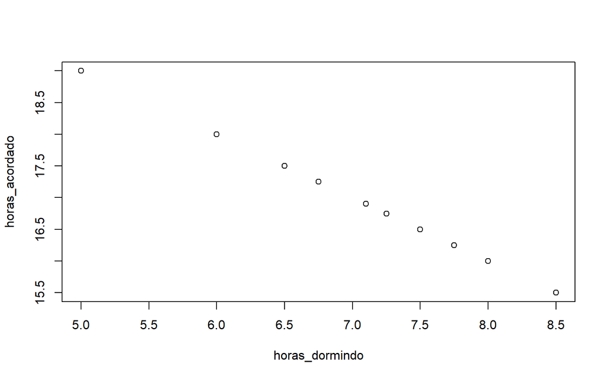

```r
# grafico dispersao no pacote Rbase
plot(horas_dormindo, horas_acordado)
```

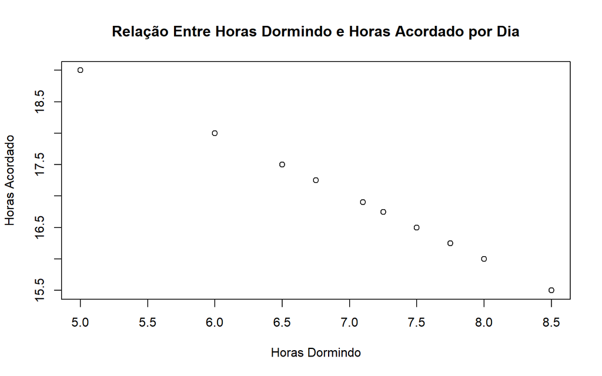

```r
# com titulo e rotulos nos eixos
plot(horas_dormindo, horas_acordado,
     main = "Relação Entre Horas Dormindo e Horas Acordado por Dia",     # titulo do grafico
     xlab = "Horas Dormindo", ylab = "Horas Acordado")     # rotulos eixos x e y
```

#### **Qual a relação entre o tamanho do pé esquerdo e o tamanho do pé direito?**

```r
# correlacionar as varivaeis
cor(tamanho_pe_esquerdo, tamanho_pe_direito)
```

```
[1] 1
```

```r
# teste de correlacao de Pearson
cor.test(tamanho_pe_esquerdo, tamanho_pe_direito)
```

```
    Pearson's product-moment correlation

data:  tamanho_pe_esquerdo and tamanho_pe_direito
t = Inf, df = 8, p-value < 2.2e-16
alternative hypothesis: true correlation is not equal to 0
95 percent confidence interval:
 1 1
sample estimates:
cor
  1
```

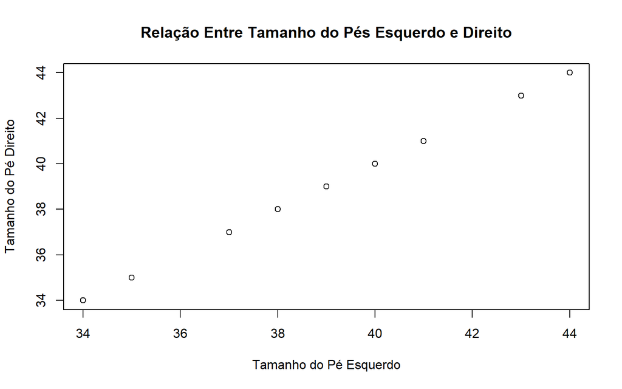

```r
# grafico dispersao no pacote Rbase
plot(tamanho_pe_esquerdo, tamanho_pe_direito,
     main = "Relação Entre Tamanho do Pés Esquerdo e Direito",
     xlab = "Tamanho do Pé Esquerdo", ylab = "Tamanho do Pé Direito")
```

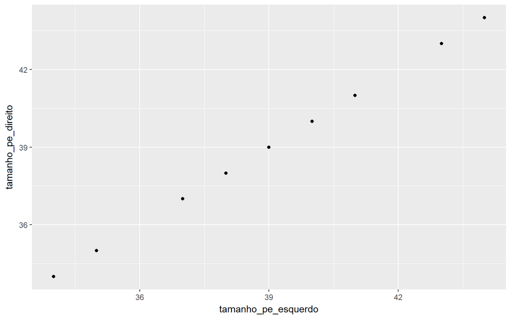

```r
# grafico dispersao no pacote Ggplot2
ggplot(correlacao_data1, aes(x = tamanho_pe_esquerdo,    # definir eixo X
                             y = tamanho_pe_direito)) +  # definir eixo Y
    geom_point()                                         # definir tipo de 'geom'
```

#### **Qual a relação entre o Nota no ENEM e Altura da pessoa?**

```r
# correlacionar as varivaeis
cor(nota_enem, altura_cm)
```

```
[1] 0.005713446
```

```r
# teste de correlacao de Pearson
cor.test(nota_enem, altura_cm)
```

```
    Pearson's product-moment correlation

data:  nota_enem and altura_cm
t = 0.01616, df = 8, p-value = 0.9875
alternative hypothesis: true correlation is not equal to 0
95 percent confidence interval:
 -0.6261654  0.6330624
sample estimates:
        cor
0.005713446
```

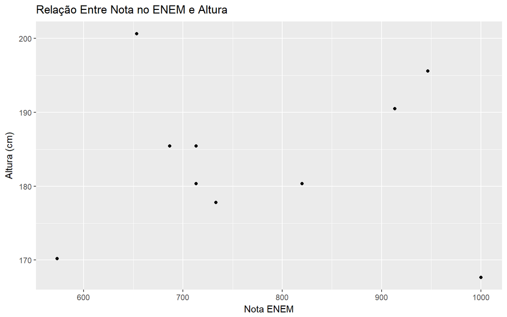

```r
# grafico de correlaco ggplot2 e titulos nos eixos
ggplot(correlacao_data1, aes(x = nota_enem,  y = altura_cm)) +
    geom_point()  +
    labs(title = "Relação Entre Nota no ENEM e Altura",
             x =  "Nota ENEM",
             y =  "Altura (cm)")
```

2017-12-10